# Day Care Fines

#### Background

Details of the Day Care Study (click to view)

The Data: Wide Format (click to view)

The Data: Long Format (click to view)

An Analysis of Variance will be performed to see whether there is a difference in means of the number of late children between the periods of No fine (labeled as control), Fine, and Post Fine. The groups that never received a fine throughout the study were not considered in this analysis.

#### Hypothesis

Let $\mu_C$ = mean of Control, $\mu_F$ = mean of Fine, and $\mu_P$ = mean of Post Fine. Then our formal hypotheses will be written as thus

$$H_0: \mu_C = \mu_F = \mu_P = \mu$$
$$H_a: \mu_i \neq \mu \ \text{for at least one} \ i \ \epsilon \ \text{{C,F,P}}$$
Our level significance will be $\alpha = 0.05$

#### Analysis

Below is a box plot of the number of parents or guardians who picked up their child late. We can see that there is a visible difference between the three.

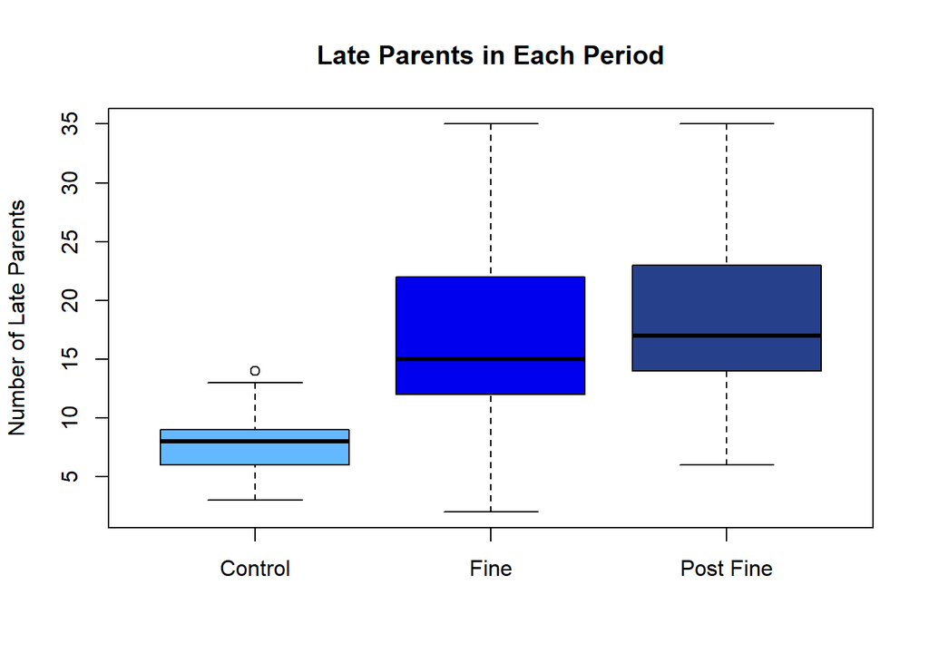

```r
boxplot(No.ofLateChildren ~ Period, data = Late, col = c("steelblue1", "blue2", "royalblue4"), main = "Late Parents in Each Period", ylab = "Number of Late Parents")
```

A summary of the statistics from these three groups are shown in the table below.

```r
pander(favstats(No.ofLateChildren ~ Period, data=Late))
```

| Period | min | Q1 | median | Q3 | max | mean | sd | n | missing |
| --- | --- | --- | --- | --- | --- | --- | --- | --- | --- |
| Control | 3 | 6 | 8 | 9 | 14 | 8 | 2.934 | 24 | 0 |
| Fine | 2 | 12 | 15 | 22 | 35 | 16.44 | 7.118 | 72 | 0 |
| Post Fine | 6 | 14 | 17 | 23 | 35 | 18.71 | 6.805 | 24 | 0 |

We can see that the summaries of the groups Fine and Post Fine are very similar, and the Control is lower in almost every statistic. To determine if the results are significant an analysis of variance was conducted.

```r
myaov <- aov(No.ofLateChildren ~ as.factor(Period), data=Late)
pander(summary(myaov))
```

Analysis of Variance Model

|  | Df | Sum Sq | Mean Sq | F value | Pr(>F) |
| --- | --- | --- | --- | --- | --- |
| **as.factor(Period)** | 2 | 1651 | 825.5 | 19.87 | 3.72e-08 |
| **Residuals** | 117 | 4861 | 41.54 | NA | NA |

To see whether an analysis of variance was appropriate in this setting these three assumptions must be satisfied.

- The samples of data properly represent their population.
- The population variance of each group is assumed to be the same.
- The data is normally distributed in each group, meaning that the residuals from the ANOVA are normally distributed.

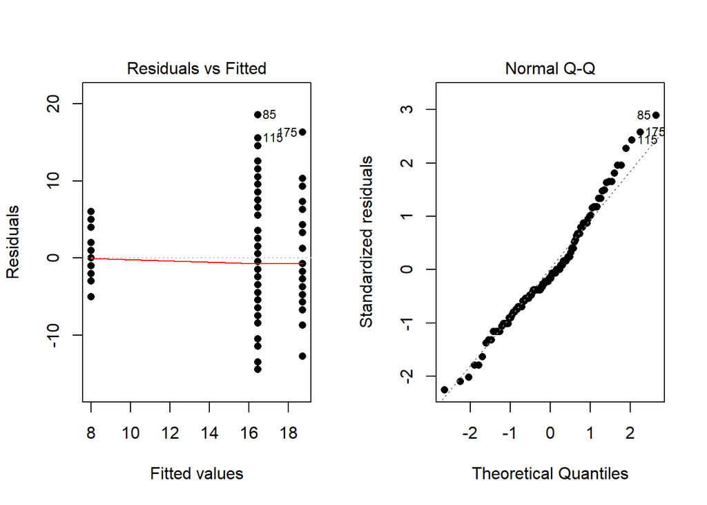

```r
par(mfrow=c(1,2))
plot(myaov, which=1:2, pch=16)
```

It is assumed that the samples taken represent the population being studied. The Residual vs Fitted graphs shows that there is a slight difference in variances. Also, the Normal Q-Q plot shows that residuals are bit skewed, but for our purposes we will consider them as normally distributed.

The difference in means can be seen in the box plot. It shows that the control is the mean that differs from the rest.

#### Interpretation

The test results shows that the control had less children waiting for their parents or guardians, than the other two periods. The results are surprising and the exact opposite of what was hoped for. The fines were put in place to encourage punctuality with parents and guardians.

It is important to note that the results of this study can be questioned based on the fact that the variances could not be assumed to be equal, and normality could also be brought into question. While all of the assumptions of an ANOVA were not met, they were close.

To further investigate the case we can observe that even after the fines were retracted children were still waiting to be picked up. Therefore it would be useful to continue observations within the control and experimental groups to see whether the mean of the post fine period will revert back to the same value as the mean of the control or if it will remain as it is.

The results of this study suggest that day care centers should seek other procedures or regulations to decrease the the amount of late parents.